# Friends

Marcin Karliński

2022-03-31

[figure not shown]

## What is Friends?

Friends is an American television sitcom created by *David Crane* and *Marta Kauffman*, which aired on NBC from September 22, 1994, to May 6, 2004, lasting ten seasons. With an ensemble cast starring *Jennifer Aniston*, *Courteney Cox*, *Lisa Kudrow*, *Matt LeBlanc*, *Matthew Perry* and *David Schwimmer*, the show revolves around six friends in their 20s and 30s who live in Manhattan, New York City.

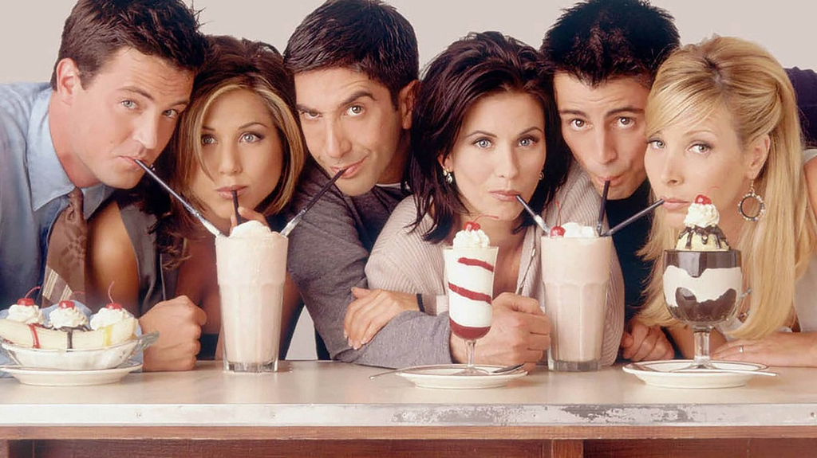

## How popular is it?

Friends consistently ranked within the top ten of the final television season ratings. *Rank* refers to how well Friends rated compared to other television series that aired during primetime hours of the corresponding television season. It is shown in relation to the total number of series airing on the then-six major English-language networks in a given season. *Viewers* refers to the average number of viewers for all original episodes, broadcast during the television season in the series’s regular timeslot. The *season premiere* is the date that the first episode of the season aired, and the *season finale* is the date that the final episode of the season aired.

Ratings table

| Season | Timeslot | Season premiere | Season finale | TV season | Rank | Viewers (in millions) | Most-watched episode |  |
| --- | --- | --- | --- | --- | --- | --- | --- | --- |
|  |  |  |  |  |  |  | Title | Viewers (in millions) |
| 1 | Thursday 8:30 pm (1–16) Thursday 9:30 pm (17–24) | September 22, 1994 | May 18, 1995 | 1994–95 | 8 | 24.3<sup>[105]</sup> | “The One Where Rachel Finds Out” | 31.3<sup>[106]</sup> |
| 2 | Thursday 8:00 pm | September 21, 1995 | May 16, 1996 | 1995–96 | 3 | 30<sup>[105]</sup> | “The One After the Superbowl” | 52.9<sup>[106]</sup> |
| 3 |  | September 19, 1996 | May 15, 1997 | 1996–97 | 4 | 24.9<sup>[105]</sup> | “The One Where Chandler Can’t Remember Which Sister” | 29.8<sup>[*citation needed*]</sup> |
| 4 |  | September 25, 1997 | May 7, 1998 | 1997–98 | 4 | 24.0<sup>[105]</sup> | “The One with Ross’s Wedding” | 31.6<sup>[106]</sup> |
| 5 |  | September 24, 1998 | May 20, 1999 | 1998–99 | 2 | 23.5<sup>[105]</sup> | “The One After Ross Says Rachel” | 30.9<sup>[106]</sup> |
| 6 |  | September 23, 1999 | May 18, 2000 | 1999–2000 | 5 | 20.7<sup>[105]</sup> | “The One with the Proposal” | 30.7<sup>[106]</sup> |
| 7 |  | October 12, 2000 | May 17, 2001 | 2000–01 | 5 | 20.2<sup>[105]</sup> | “The One with Monica and Chandler’s Wedding” | 30.1<sup>[106]</sup> |
| 8 |  | September 27, 2001 | May 16, 2002 | 2001–02 | 1 | 24.5<sup>[105]</sup> | “The One Where Rachel Has a Baby” | 34.9<sup>[106]</sup> |
| 9 |  | September 26, 2002 | May 15, 2003 | 2002–03 | 2 | 21.8<sup>[105]</sup> | “The One Where No One Proposes” | 34.0<sup>[106]</sup> |
| 10 |  | September 25, 2003 | May 6, 2004 | 2003–04 | 4 | 22.8<sup>[105]</sup> | “The Last One” | 52.5<sup>[4]</sup> |